# Seasonal Model.Forecasting

©Alexander Doynikov,dep. CS, MSU

March 5, 2021

# 1 Сезонные ARMA модели

При помощи общей модели авторегресии-скользящего среднего
$$φ(B)x_{t}=θ(B)\epsilon_{t}$$
можно вполне адекватно описывать достаточно широкий класс временных рядов. Но если задаться построением наиболее экономичной (с точки зрения количества оцениваемых параметров) модели, то в некоторых случаях небольшая ее модификация позволяет значительно уменьшить число параметров модели. В первую очередь это касается так называемых сезонных временных рядов, в которых наблюдается определенное сходство в поведении наблюдений, разделенных по времени на фиксированный пероид времени s. Пусть во временном ряде $z_{t}$ нам удалось связать наблюдения, отстоящие друг от друга на время s в модель
$$Φ_{P}(B^{s})∇_{s}^{D}z_{t}=Θ_{Q}(B^{s})a_{t} (*)$$
Где $Φ_{P}(B^{s})$ и $Θ_{Q}(B^{s})$ полиномы степени $P,Q$ соответственно вида
$$Φ_{P}(B^{s})=1-Φ_1B^{s}-...-Φ_{P}B^{Ps}$$
$$Θ_{Q}(B^{s})=1-Θ_1B^{s}-...-Θ_{Q}B^{Qs}$$
которые удовлетворяют условиям стационарности и обратимости, a
$$∇_{s}^{D}=(1-B^{s})^{D}$$
оператор сезонной разности порядка $D$

Ошибки $a_{t}$ здесь не обязательно должны быть некоррелированными, так как наличие связи между переменными через период времени s не означает, что нет связи между соседними значениями ряда $z_{t}$ и $z_{t-1}$ или переменными, отстоящими друг от друга на два, три и т.д. моментами времени. Чтобы учесть и эту связь мы вводим еще одну модель
$$φ(B)∇^{d}a_{t}=θ(B)\epsilon_{t}$$

где $\epsilon_{t}$- уже белый шум, а $φ(B)$ и $θ(B)$ полиномы по $B$ степени $p$ и $q$ соответсвенно, также удовлетворяющие условиям стационарности и обратимости. Подставляя последнее выражение в (*) получим окончательную общую модель
$$φ(B)Φ_{P}(B^{s})∇^{d}∇_{s}^{D}z_{t}=Θ_{Q}(B^{s})θ(B)\epsilon_{t}$$
(**)

которую и называют сезонной моделью авторегресии проинтегрированного скользящего среднего и обозначают $SARMA(p,q,d)(P,Q,D)$

Таким образом мы задаем мультипликативную модель сезонности.

## 1.1 Идентификация сезонных моделей

### 1.1.1 Сезоннные модели скользяшего среднего

Для идентификация сезонных моделей также широко используется АКФ и ЧАКФ. ввeдем понятие производящей функции автокорреляций. `Определение.` Производящей функцией АКФ называется функция вида
$$\gamma(z)= \sum_{k=-\infty}^{\infty}c_kz^k$$
Справедливо следующее утверждение. Если временной ряд задан в виде моделт линейного фильтра типа скользящего среднего
$$x_t = \Psi(B)\epsilon(t)= (1+\Psi_1B+\Psi_2B^2+.....)\epsilon_t$$
тогда
$$\gamma(z)=\sigma^2\Psi(B)\Psi(B^{-1})$$

Для выяснения характеров их поведения ACF и PACF нам поможет тот факт, что производящая функция автоковариаций процесса заданного мультипликативно равна произведению производящих функций его компонент. Т.е. если компоненты
$$φ(B)∇^{d}a_{t}=θ(B)\epsilon_{t}$$
$$\Phi_{P}(B^{s})\Delta^{D}z_t=\Theta_{Q}(B^s)a_t$$
имеют производящие функции АКФ $γ(B),Γ(B)$ соответсвенно, то производящая функция автоковариаций процесса $z_{t}$ равна $γ(B)Γ(B)$

Проще всего найти выражение для модели сезонного скользящего среднего.
$$x_t=\Theta_Q(B^s)\theta_q(B)\epsilon_t$$
. Для такой модели производящие функции автокорреляций равны
$$γ(B)=\sigma^2_{\epsilon}\theta_q(B)\theta(B^{-1})$$
,
$$\Gamma(B)=\sigma^2_{a} \Theta_Q(B^s)\Theta_Q(B^{-s})$$
Cледовательно для всего процесса она будет
$$C(B)=\sigma^2_{\epsilon}\sigma^2_{a}\theta_q(B)\Theta_Q(B^s)\theta_q(B^{-1})\Theta_Q(B^{-s})$$

### 1.1.2 Пример SARMA(0,1,0)(0,1,0)

В этой модели $\theta_q(B)=1 - \theta_1B$,$\Theta_Q(B^s)=1 - \Theta_1B^s$ поэтому
$$c(B)= \sigma^2_{\epsilon}\sigma^2_{a}(1 - \theta_1B)(1 - \theta_1B^{-1})(1 - \Theta_1B^s)(1 - \Theta_1B^{-s})$$
Перемножая полиномы, получим, что отличны от нуля будут коэффициенты при степени $0,1,,...,s-1,s,s+1$

```r
  library(polynom)

  season <- 7
  theta1 <- 0.6
  Theta1 <- 0.8
  ma <- c(1,theta1)
  sma <- c(1,rep(0,season-1),Theta1)
  ma <- as.polynomial(ma)
  sma <- as.polynomial(sma)
  ma
```

```
## 1 + 0.6*x
```

```r
  sma
```

```
## 1 + 0.8*x^7
```

```r
  sma_ma <- ma *sma
  sma_ma
```

```
## 1 + 0.6*x + 0.8*x^7 + 0.48*x^8
```

```r
  ma_vec <- sma_ma[2:length(sma_ma)]
  ma_vec
```

```
## [1] 0.60 0.00 0.00 0.00 0.00 0.00 0.80 0.48
```

Оценим ACF по модели

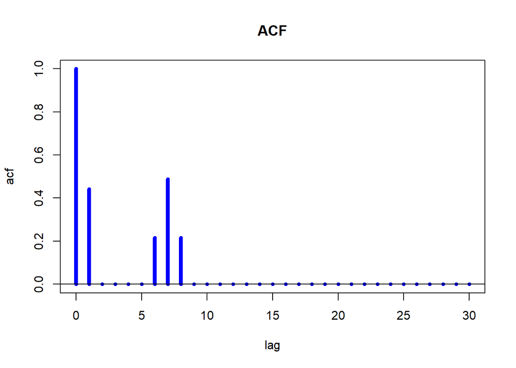

```r
  model <- list(ma=ma_vec)
  acf <- ARMAacf(ma = ma_vec,lag.max = 30,pacf = FALSE)
  pacf <- ARMAacf(ma = ma_vec,lag.max = 30,pacf = TRUE)
  m <- length(acf)
  matplot(0:(m-1),acf,type= 'h',main = 'ACF',col = 'blue',lwd = 5,xlab = 'lag',ylab='acf')
        abline(h = 0,untf = TRUE,col = 'black')
```

Смоделируем сезонный ряд

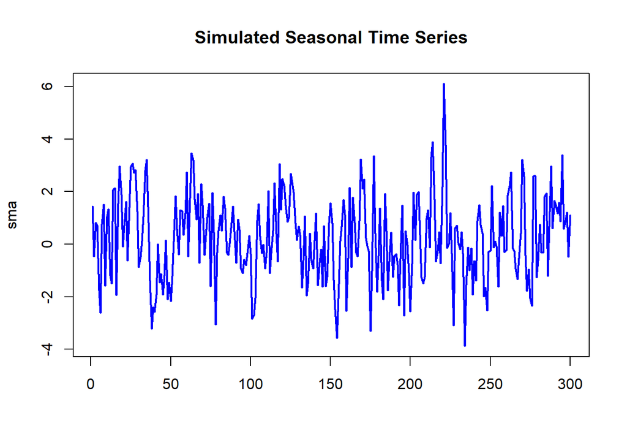

```r
   sma <- arima.sim(model = list(ma=ma_vec),n = 300)
   matplot(sma,type = "l",col = "blue",main = "Simulated Seasonal Time Series",lwd = 2)
```

Оценим ACF по ряду

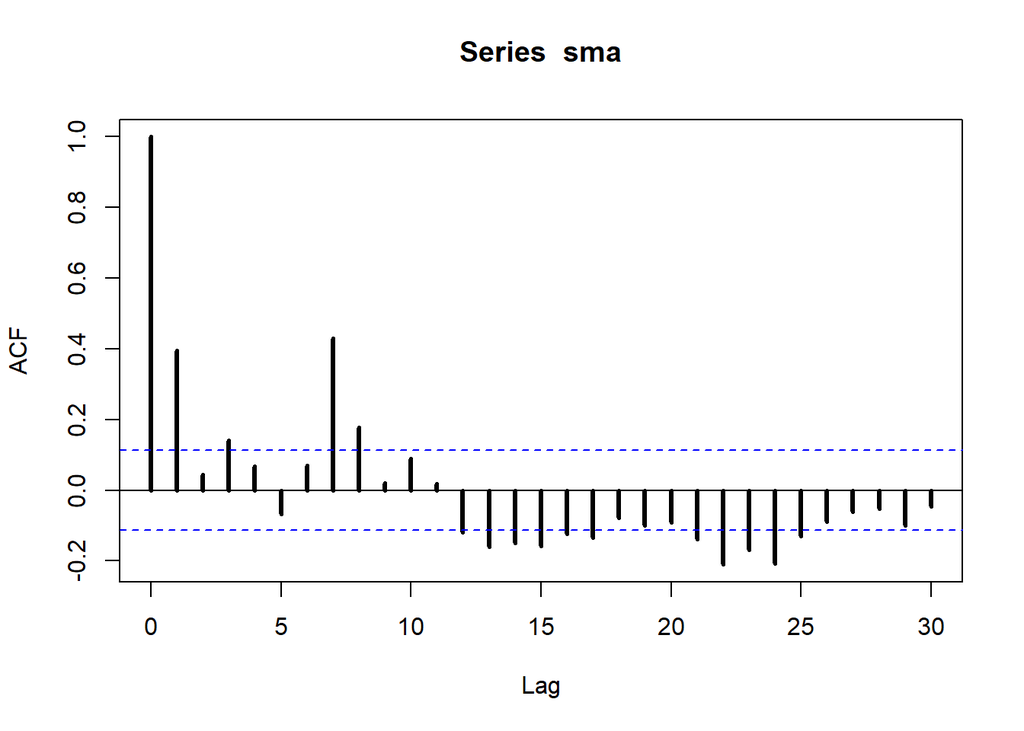

```r
acf(sma,lag.max=30,lwd = 3)
```

Для сезонного скользящего среднего произвольного порядка SARMA(0,Q,0)(0,q,0) c периодом сезонности $s$ нетрудно убедиться, что отличны от нуля будут тольк значения ACF на задержках
$$0,1,...,q,...,s-q,...,s-1,s,s+1,...,s+q,....,sQ-q,...,sQ-1,sQ,sQ+1,...,sQ+q$$

Для PACF без доказательсва примем на веру тот факт, что PACF процесса сезонного сколящего среднего экспоненциально затухает.

### 1.1.3 Сезоннные модели авторегрессии

Здесь нам опять помогут уравнения Юла-Уокера из прошлой лекции. Из них немедленно следует, что PACF процесса SARMA(p,0)(P,0) сезонной авторегресссии с периодом сезонности $s$ вида
$$(1-\Phi_1B^s+\Phi_2B^{2S}+...+\Phi_PB^{Ps})x_t=a_t$$
$$(1-\phi_1B-\phi_2B^2-...-\phi_pB^P)a_t=\epsilon_t$$
будет отлична от нуля на задержках
$$0,1,...,p,...,s-p,...,s-1,s,s+1,...,s+p,....,sP-p,...,sP-1,sP,sP+1,...,sP+p$$

Для ACF аналогично доказывается, как и в Лекции 3,только более громоздко, что ACF представляет собой экспоненциально затухающие косинусоиды.

#### 1.1.3.1 Пример SARMA(1,0,0)(1,0,0)

Модель имеет вид
$$x_t=\Phi_1x_{t-s} + a_t$$
$$a_t= \phi_1a_{t-1}+\epsilon_t$$

```r
  library(polynom)

  season <- 7
  phi1 <- 0.4
  Phi1 <- -0.3
  ar <- c(1,phi1)
  sar <- c(1,rep(0,season-1),Phi1)
  ar <- as.polynomial(ar)
  sar <- as.polynomial(sar)
  ar
```

```
## 1 + 0.4*x
```

```r
  sar
```

```
## 1 - 0.3*x^7
```

```r
  sar_ar <- ar *sar
  sar_ar
```

```
## 1 + 0.4*x - 0.3*x^7 - 0.12*x^8
```

```r
  ar_vec <- sar_ar[2:length(sar_ar)]
  ar_vec
```

```
## [1]  0.40  0.00  0.00  0.00  0.00  0.00 -0.30 -0.12
```

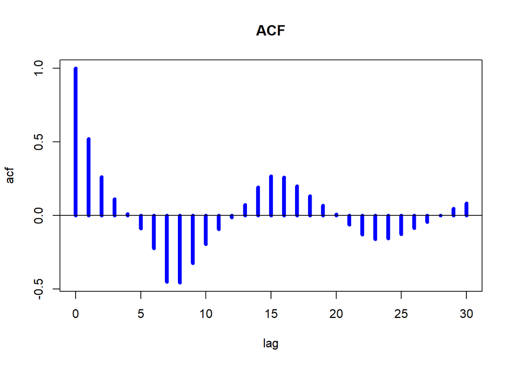

```r
  modelSAR <- list(ar=ar_vec)

  acf <- ARMAacf(ar = ar_vec,lag.max = 30,pacf = FALSE)
  pacf <- ARMAacf(ar = ar_vec,lag.max = 30,pacf = TRUE)
  m <- length(acf)
  matplot(0:(m-1),acf,type= 'h',main = 'ACF',col = 'blue',lwd = 5,xlab = 'lag',ylab='acf')
        abline(h = 0,untf = TRUE,col = 'black')
```

Смоделируем сезонный ряд

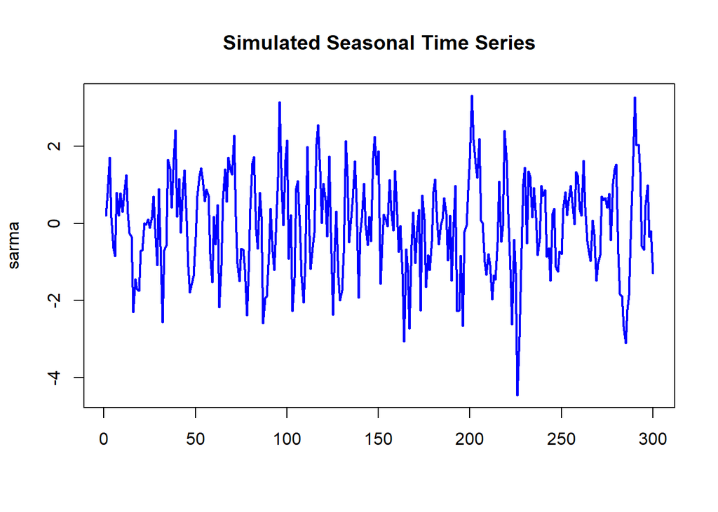

```r
   sarma <- arima.sim(model = modelSAR,n = 300)
   matplot(sarma,type = "l",col = "blue",main = "Simulated Seasonal Time Series",lwd = 2)
```

Оценим ACF,PACF по ряду

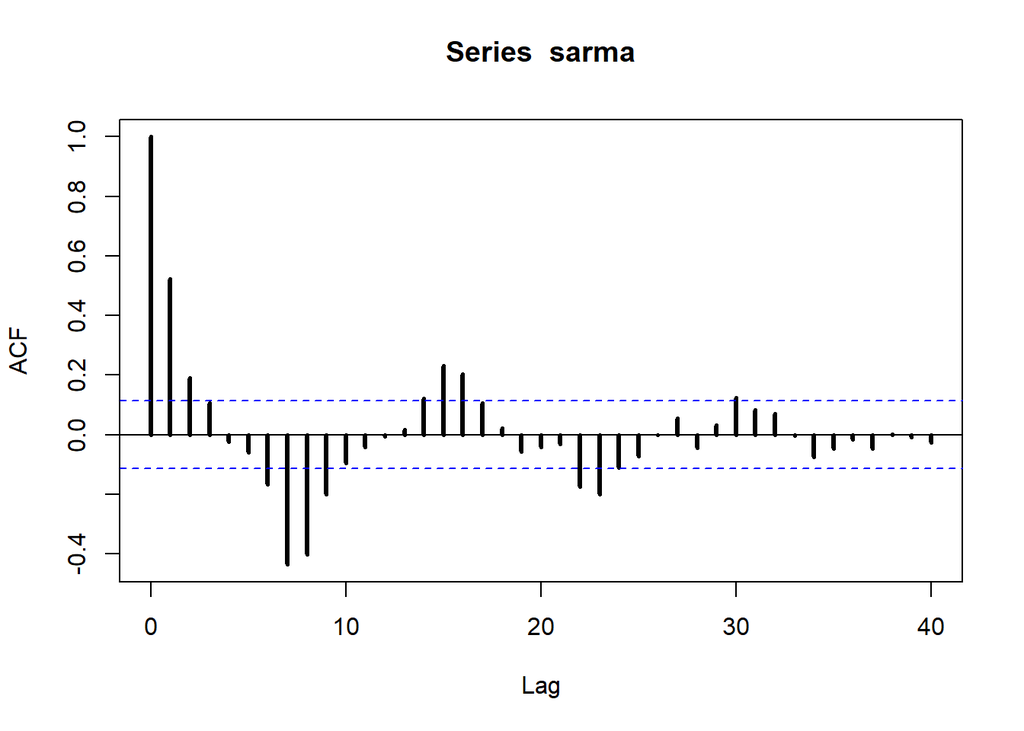

```r
acf(sarma,lag.max=40,lwd = 3)
```

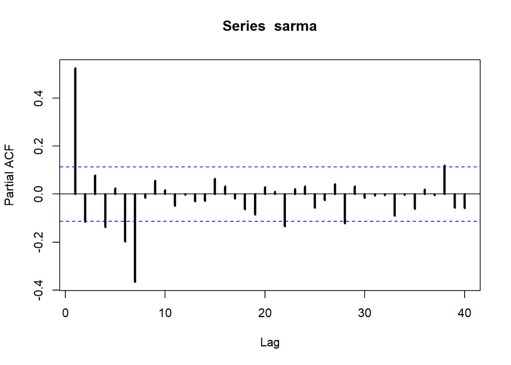

```r
pacf(sarma,lag.max=40,lwd = 3)
```

Помочь освоить идентификацию сезонных моделей поможет следующий фрейм https://shiny.ilykei.com/ANDoynikov/ARMA_Model/SARMA_Identification/

### 1.1.4 Оценка сезонных моделей

При оценке сезонных моделей используются те же методы, что и для несезонных моделей рядов. Об этом была Лекция 3. Ведь сезонные ряды это просто экономная (с точки зрения числа параметоров) форма записи обычной ARMA модели. Это методы моментов (Юла-Уокера) для сезонной авторегрессии, метод наименьших квадратов и максимального правдоподобия для произвольных сезонных моделей.

Осталось только продемострировать идентификацию и оценку параметров реального экономического сезонного ряда:Импорт в млрд. долларов Российской Федерации.

Информация о динамике объемов импорта и экспорта отражается в отчете о внешнеторговом балансе государства. Внешнеторговый баланс - разница экспорта и импорта товаров. Если экспорт превышает импорт, то образуется положительное сальдо внешнеторгового баланса или внешнеторговый профицит. Если импорт превышает экспорт, то возникает отрицательное сальдо внешнеторгового баланса или внешнеторговый дефицит. В России экспорт традиционно превышает импорт за счет масштабных экспортных поставок газа, нефти и металлов. Соответственно, сальдо торгового баланса РФ сильно зависимо от мировых цен на данные сырьевые группы товаров.

Читаем данные из файла

```r
import <- read.csv("./import.csv", header = TRUE)
head(import)
```

[output not shown]

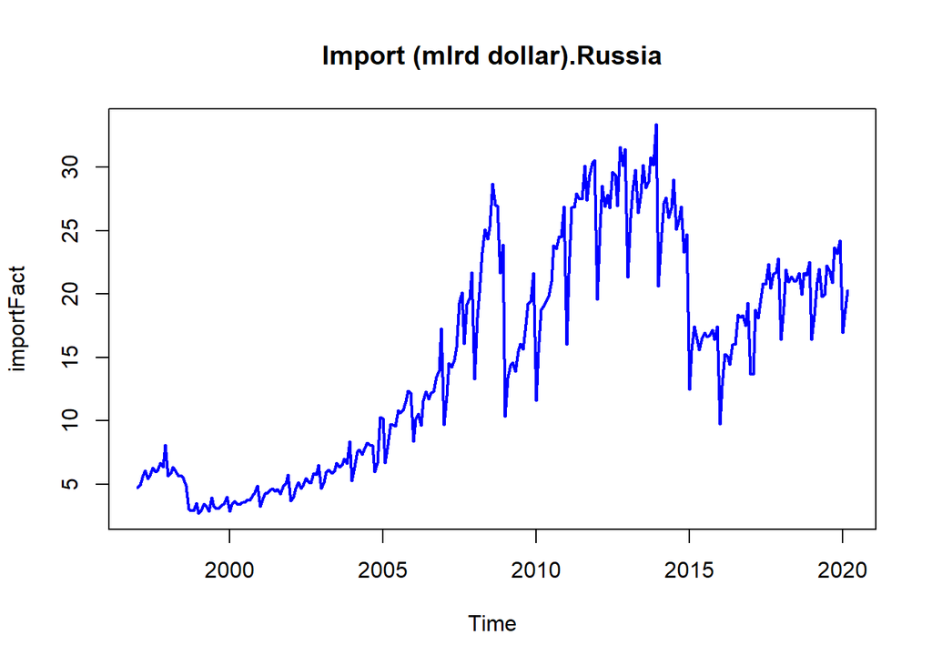

```r
importFact <- ts(import$Fact ,start= c(1997,1),frequency =12)
plot(importFact ,type = "l", col = "blue",lwd = 2,main = "Import (mlrd dollar).Russia")
```

Нестационарность явно присутствует в ряде. Возьмем обычную разность
$$y_t= x_t-x_{t-1}$$

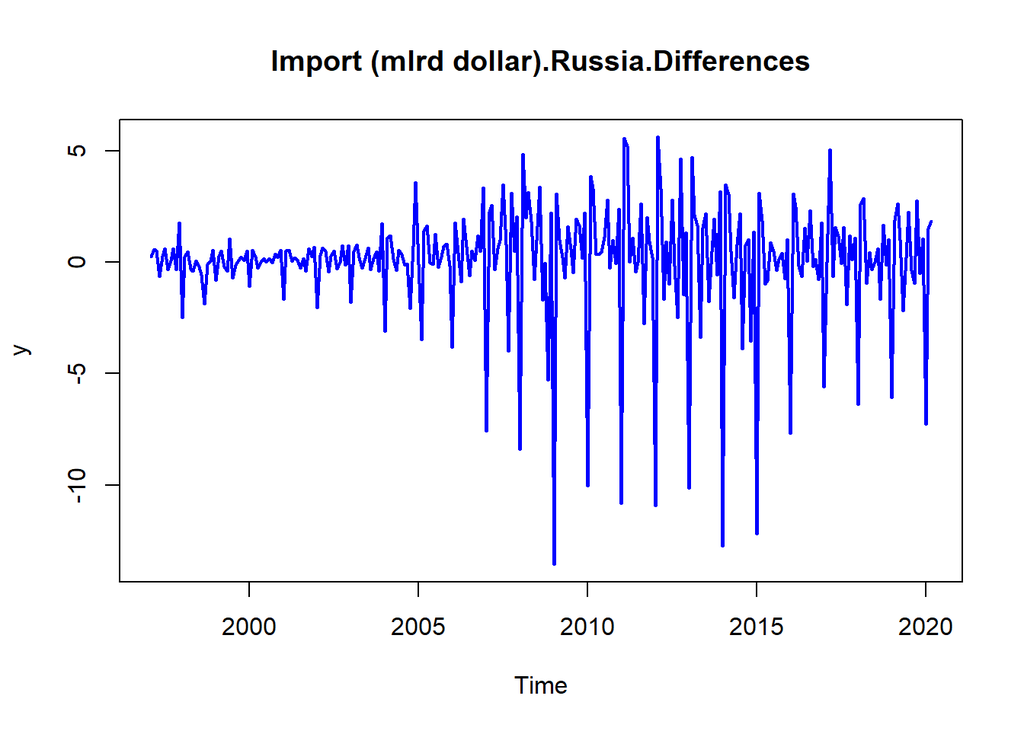

```r
y <- diff(importFact)
plot(y ,type = "l", col = "blue",lwd = 2,main = "Import (mlrd dollar).Russia.Differences")
```

Заметна нестационарность в сезонности с периодом 12. Возьмем сезонную разность
$$z_t= y_t-y_{t-12}$$

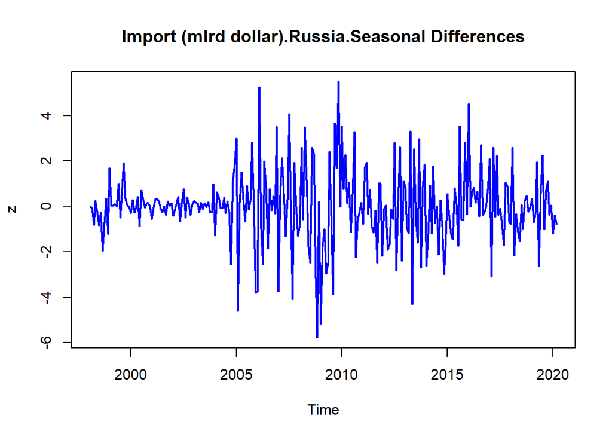

```r
z <- diff(y,lag = 12)
plot(z ,type = "l", col = "blue",lwd = 2,main = "Import (mlrd dollar).Russia.Seasonal Differences")
```

Нестационарность по дисперсии (или как сейчас принято говорить по волатильности). Но модели таких рядов мы пока не изучали. Поэтому возьмем выделим подряд с 2006 года, после которого волатильность на вид постоянна.

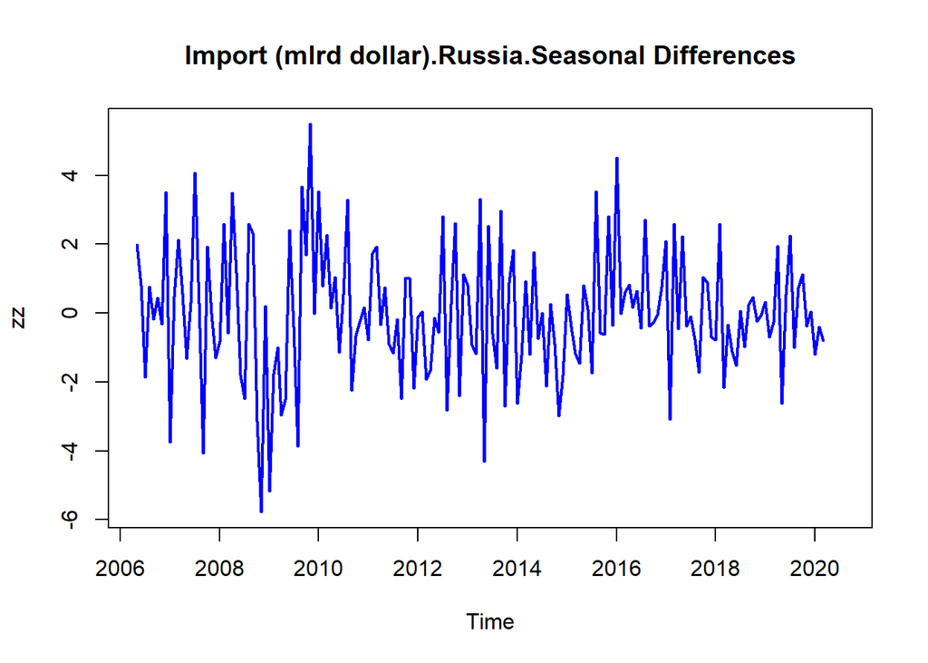

```r
zz <- z[100:271]
zz <- ts(zz,start= c(2006,5),frequency = 12 )
plot(zz ,type = "l", col = "blue",lwd = 2,main = "Import (mlrd dollar).Russia.Seasonal Differences")
```

Оценим ACF,PACF

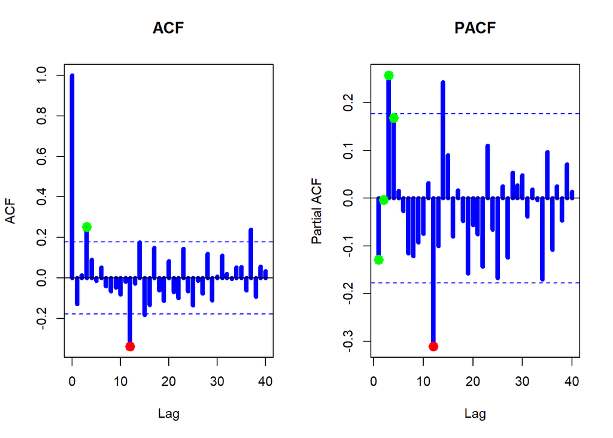

```r
zz <- zz[1:122]
par(mfrow = c(1, 2), cex = 0.9)
zacf = acf(zz, lwd = 5,main = "ACF",col = "blue",lag.max=40)
points(3,zacf$acf[4],col = "green",lwd = 5)
points(12,zacf$acf[13],col = "red",lwd = 5)
zpacf= pacf(zz,lwd = 5,main = "PACF",col = "blue",lag.max=40)
points(1:4,zpacf$acf[1:4],col = "green",lwd = 5)
points(12,zpacf$acf[12],col = "red",lwd = 5)
```

Более выразительна PACF. Попробуем оценить модель сезонной авторегрессии. Период сезонности очевидно 12. Порядок сезонной авторегрессии 1. Порядок несезонной авторегрессии 3 или 4, возьмем 4. Оцениваем эту модель методом максимального правдоподобия.

```r
modelimport <- arima(zz,order = c(4,0,0),seasonal = list(order= c(1,0,0),period = 12 ),method = "ML")
modelimport$coef
```

```
##         ar1         ar2         ar3         ar4        sar1   intercept
## -0.21314960  0.05361242  0.26716343  0.12983369 -0.36516922 -0.02593345
```

Насколько значимы оцененные параметры можно косвенно судить по ковариационной матрице оценок

```r
modelimport$var.coef
```

```
##                     ar1           ar2           ar3           ar4          sar1
## ar1        0.0081032270  0.0013973010 -0.0004900204 -0.0018619296  0.0006964960
## ar2        0.0013973010  0.0077998471  0.0012787193 -0.0004803857 -0.0005816171
## ar3       -0.0004900204  0.0012787193  0.0077894834  0.0015345285  0.0002796146
## ar4       -0.0018619296 -0.0004803857  0.0015345285  0.0079744100  0.0008899855
## sar1       0.0006964960 -0.0005816171  0.0002796146  0.0008899855  0.0075167141
## intercept  0.0002499133  0.0003809302  0.0004829565  0.0004676211  0.0005532860
##              intercept
## ar1       0.0002499133
## ar2       0.0003809302
## ar3       0.0004829565
## ar4       0.0004676211
## sar1      0.0005532860
## intercept 0.0256952317
```

P-Значения для проверки значимости вызывать отдельно или вычислять самостоятельно. Так как оценки ассимптотически нормальные, дисперсии ошибок стоят на диагонале матрицы ковариаций. Поэтому для получения р-значений для проверки значимости делаем следующую команду

```r
(1-pnorm(abs(modelimport$coef)/sqrt(diag(modelimport$var.coef))))
```

```
##          ar1          ar2          ar3          ar4         sar1    intercept
## 8.945718e-03 2.719098e-01 1.234677e-03 7.298536e-02 1.266044e-05 4.357382e-01
```

Другой способ такой проверки это метод coeftest из библиотеки lmtest

```r
library("lmtest")
coeftest(modelimport)
```

```
##
## z test of coefficients:
##
##            Estimate Std. Error z value  Pr(>|z|)
## ar1       -0.213150   0.090018 -2.3679  0.017891 *
## ar2        0.053612   0.088317  0.6070  0.543820
## ar3        0.267163   0.088258  3.0271  0.002469 **
## ar4        0.129834   0.089300  1.4539  0.145971
## sar1      -0.365169   0.086699 -4.2119 2.532e-05 ***
## intercept -0.025933   0.160297 -0.1618  0.871476
## ---
## Signif. codes:  0 '***' 0.001 '**' 0.01 '*' 0.05 '.' 0.1 ' ' 1
```

Остатки после исключения модели и усредненная сумма квадратов остатков

```r
par(mfrow = c(1, 1), cex = 0.9)
modelimport$sigma2
```

```
## [1] 3.293249
```

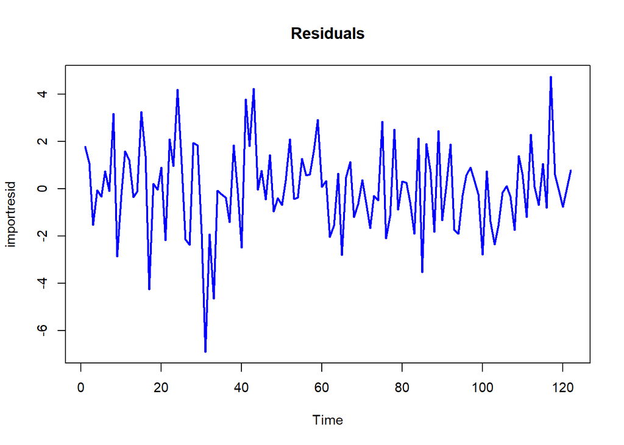

```r
importresid <- modelimport$residuals
plot(importresid ,type = "l", col = "blue",lwd = 2,main = "Residuals")
```

проведем тест Льюнг-Бокса остатков и постром qq-график

```r
  Box.test(importresid, lag = 16, type = "Ljung-Box", fitdf = 2)
```

```
##
##  Box-Ljung test
##
## data:  importresid
## X-squared = 17.32, df = 14, p-value = 0.2395
```

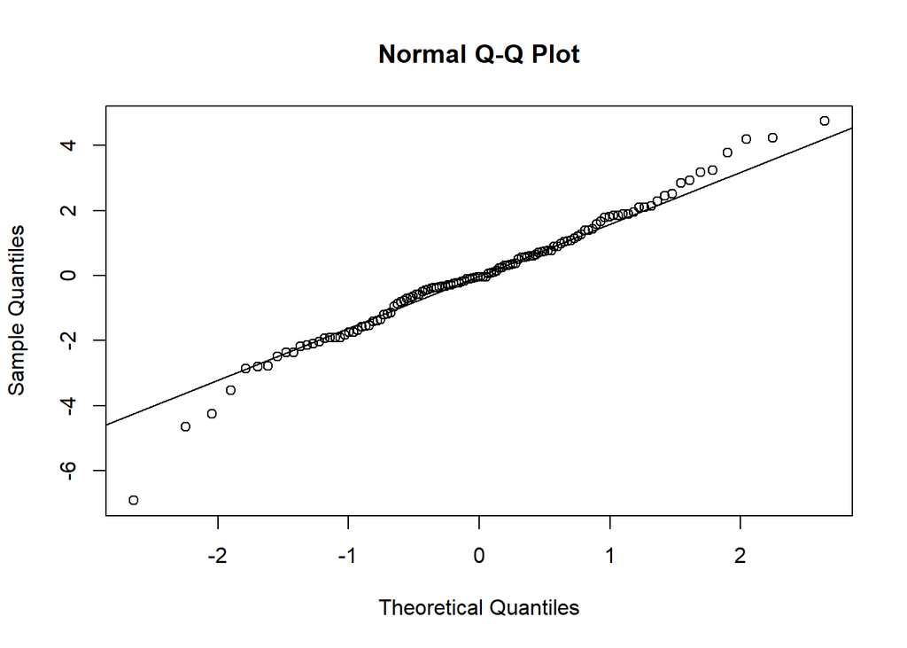

```r
  qqnorm(importresid)
  qqline(importresid)
```

Остатки явно не нормально распределены, имеют очень тяжелые хвосты Построим ACF,PACF остатков

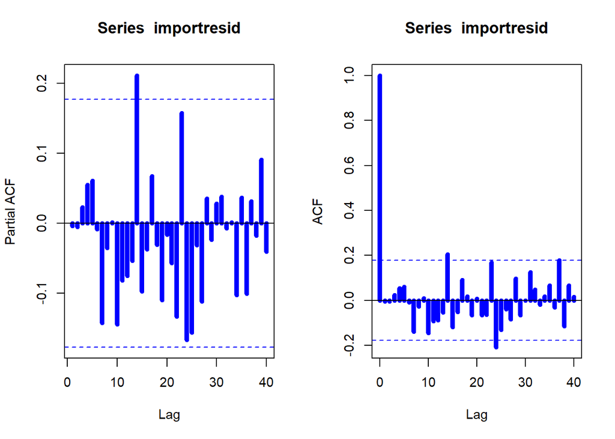

```r
par(mfrow = c(1, 2), cex = 0.9)
  pacf(importresid,lwd = 5,lag.max = 40, col = "blue")
  acf(importresid,lwd = 5,lag.max = 40, col = "blue")
```

Похоже модель выбрана не лучшим образом. Попробуем другую модель. Порядок сезонного скользящего среднего 1, а не сезонного 3. Повторим оценку уже другой модели.

```r
modelimport2 <- arima(zz,order = c(0,0,3),seasonal = list(order= c(0,0,1),period = 12 ),method = "ML")
coeftest(modelimport2)
```

```
##
## z test of coefficients:
##
##            Estimate Std. Error z value  Pr(>|z|)
## ma1       -0.267390   0.090592 -2.9516  0.003162 **
## ma2        0.041420   0.086667  0.4779  0.632707
## ma3        0.196688   0.085320  2.3053  0.021150 *
## sma1      -0.756290   0.139178 -5.4340 5.512e-08 ***
## intercept -0.056275   0.052699 -1.0679  0.285584
## ---
## Signif. codes:  0 '***' 0.001 '**' 0.01 '*' 0.05 '.' 0.1 ' ' 1
```

```r
par(mfrow = c(1, 1), cex = 0.9)
modelimport2$sigma2
```

```
## [1] 2.748341
```

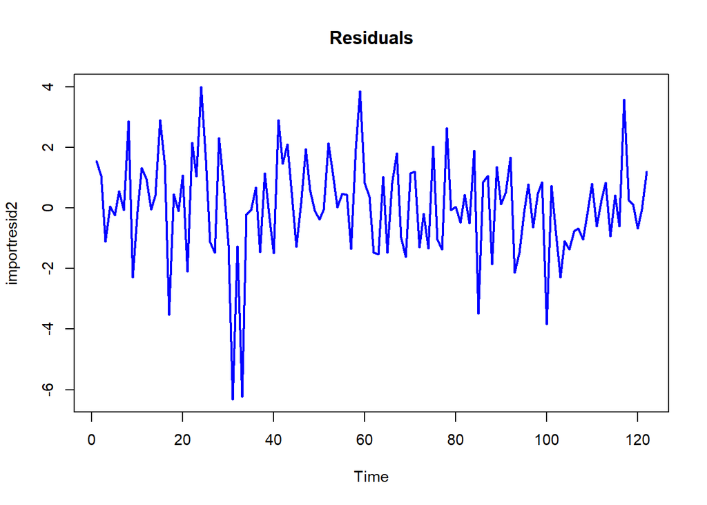

```r
importresid2 <- modelimport2$residuals
plot(importresid2 ,type = "l", col = "blue",lwd = 2,main = "Residuals")
```

```r
  Box.test(importresid2, lag = 16, type = "Ljung-Box", fitdf = 2)
```

```
##
##  Box-Ljung test
##
## data:  importresid2
## X-squared = 14.098, df = 14, p-value = 0.4424
```

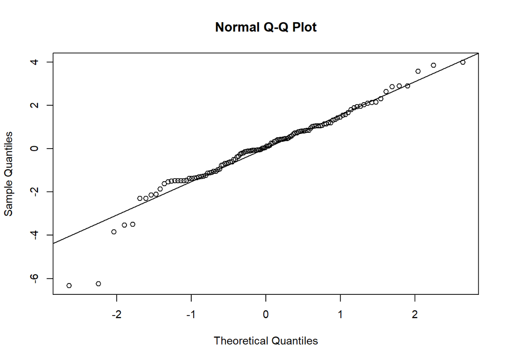

```r
  qqnorm(importresid2)
  qqline(importresid2)
```

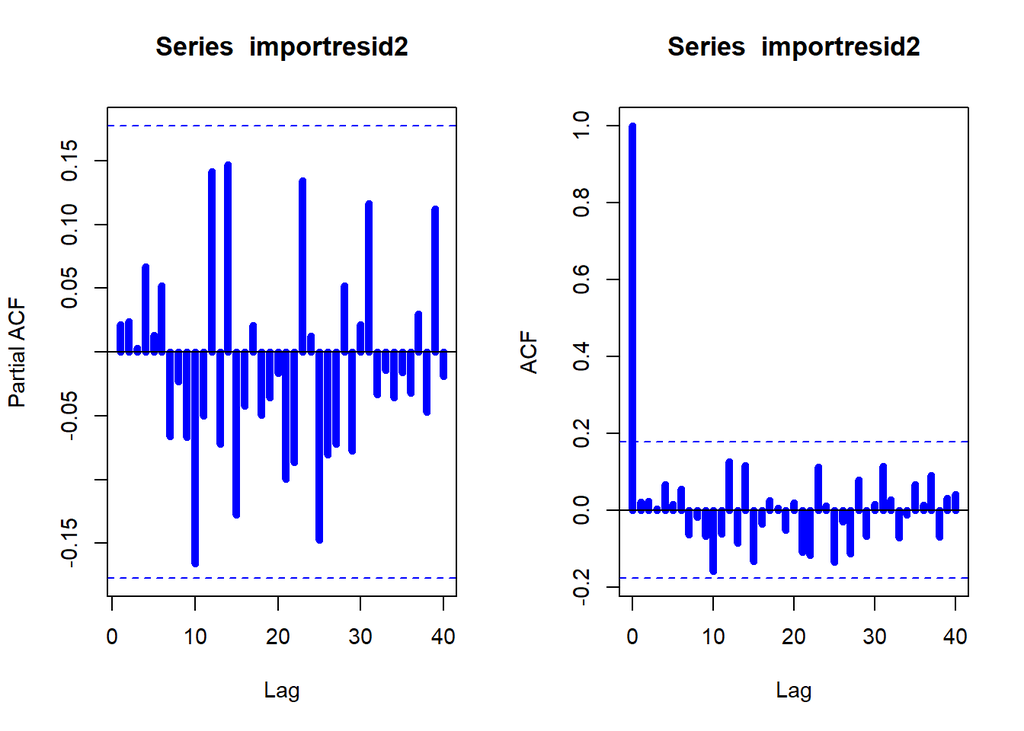

```r
par(mfrow = c(1, 2), cex = 0.9)
  pacf(importresid2,lwd = 5,lag.max = 40, col = "blue")
  acf(importresid2,lwd = 5,lag.max = 40, col = "blue")
```

Ну вот и так мы оценили достаточно адекватную модель SARMA(3,0)(0,1) остатки гипотезе, что это белый шум не противоречат, но их нормальность явно под вопросом. Тест Шапиро (см Лекцию 2.) нормальности это подтверждает, точнее гипотеза о нормальности остатков отвергается.

```r
 shapiro.test(importresid2)
```

```
##
##  Shapiro-Wilk normality test
##
## data:  importresid2
## W = 0.95343, p-value = 0.0003437
```

### 1.1.5 Сравнение моделей. Информационный критерий Хироцуго Акаике

Для сравнения результатов оценки по нескольким моделям и выбора лучшей из них Х.Акаике (1974) был предложен следующий критерий. В общем случае AIC:
$$\mathit{AIC} = 2k - 2\ln(L)\,$$
где $k$ — число параметров в статистической модели, и $L$ — максимизированное значение функции правдоподобия модели.

Будем полагать, что ошибки модели нормально и независимо распределены. Пусть $n$ — число наблюдений и RSS-
$$\mathit{RSS} = \sum_{i=1}^n \hat{\varepsilon}_i^2$$
, остаточная сумма квадратов. Далее мы предполагаем, что дисперсия ошибок модели неизвестна, но одинакова для всех них. Следовательно:
$$\mathit{AIC}=2k + n[\ln(2\pi \mathit{RSS}/n) + 1]\,$$
. В случае сравнения моделей на выборках одинаковой длины, выражение можно упростить, выкидывая члены зависящие только от n:
$$\mathit{AIC}=2k + n[\ln(\mathit{RSS})]\,$$
. Таким образом, критерий не только вознаграждает за качество приближения, но и штрафует за использование излишнего количества параметров модели. Считается, что наилучшей будет модель с наименьшим значением критерия AIC. Сравним значения критерия для двух моделей, которые мы оценили выше.

```r
  modelimport$aic
```

```
## [1] 507.6179
```

```r
  modelimport2$aic
```

```
## [1] 491.9337
```

Что потверждает наши предположения, о том, что вторая модель предпочтительней.Стоит отметить, что абсолютное значение AIC не имеет смысла — он указывает только на относительный порядок сравниваемых моделей.

# 2 Непараметрические модели прогнозирования

## 2.1 Экспоненциальное сглаживание

Пусть $y_t$ одномерный временной ряд. Экспоненциальным сглаживанием на период $t+h$, основываясь на знании значений процесса до момента времени $t$,называется построение прогноза по переменной $\widehat a_t$.
$$\widehat{y}_{t+h}=\widehat a_t$$
,
Переменная $\widehat a_t$ рекурсивно пересчитывается.
$$\widehat a_t= \alpha y_t+(1-\alpha)\widehat y_t=\alpha y_t+(1-\alpha)\widehat a_{t-1}$$
где $0 < \alpha <1$ называется параметром сглаживания. Начальное значение $\widehat a_1= y_1$. Эквивалентная запись модели прогнозирования называется error correction form:
$$\widehat a_t= \widehat a_{t-1}+\alpha (y_t-\widehat a_{t-1})=\widehat a_{t-1}+ \alpha (y_t- \widehat y_t) = \widehat a_{t-1} +\alpha \epsilon_t$$
Экспоненциальное сглаживание это частный случай метода Хольта-Уинтерса (Holt-Winters) для несезонных рядов без ярко выраженного тренда. Посмотрим пример прогнозирование ряда.

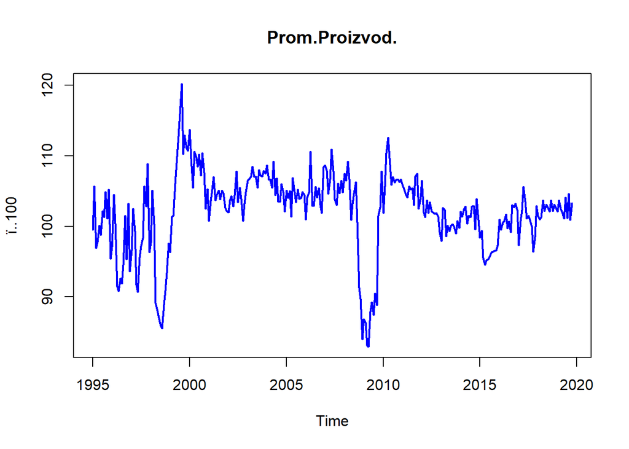

```r
promData <- read.csv("./PromProizv.csv")
promData <- ts(promData,start= c(1995,1),frequency = 12)
plot.ts(promData,col = "blue",lwd = 2,type = "l",main = "Prom.Proizvod.")
```

```r
past <- window(promData,end = c(2005,1))
future <- window(promData,start = c(2005,2))
alpha <-0.2
model <- HoltWinters(past,alpha = alpha,beta = FALSE, gamma= FALSE)
filter(alpha*past,filter = 1-alpha,method = "recursive",init = past[1])
```

```
##            Jan       Feb       Mar       Apr       May       Jun       Jul
## 1995  99.50000 100.74000  99.97200  99.53760  99.65008  99.48006 100.02405
## 1996  99.95515 100.86412 100.77130  98.91704  97.29363  96.35490  95.46392
## 1997  96.79765  97.93812  98.21049  96.90840  95.66672  95.65337  95.96270
## 1998  99.67110 100.75688 100.66550  98.35240  96.28192  94.42554  92.72043
## 1999  93.33148  94.94518  96.25615  98.22492 100.37993 102.86395 105.49116
## 2000 110.80084 110.56067 109.54854 109.75883 109.76706 109.51365 109.65092
## 2001 105.96000 105.48800 105.43040 105.74432 105.33546 105.16836 105.15469
## 2002 103.58418 103.60734 103.74588 103.55670 103.72536 104.54029 104.31223
## 2003 104.38588 104.84871 105.29896 105.93917 106.15134 106.34107 106.17286
## 2004 107.41053 107.24842 107.13874 106.81099 107.28879 106.71103 106.72883
## 2005 104.86482
##            Aug       Sep       Oct       Nov       Dec
## 1995 100.27924 101.20339 101.18271 101.98617 100.66894
## 1996  95.27114  96.51691  96.27353  97.65882  96.84706
## 1997  96.43016  98.28413  99.18730 101.12984 100.16387
## 1998  91.27634  90.80108  90.82086  91.33669  92.58935
## 1999 108.43293 108.80634 109.62507 109.92006 110.07605
## 2000 109.16074 109.40859 109.04687 107.73750 107.25000
## 2001 104.88375 104.92700 104.88160 104.42528 103.98023
## 2002 104.54978 104.41983 103.69586 103.59669 103.85735
## 2003 106.53828 106.67063 106.75650 106.98520 107.08816
## 2004 106.08306 105.56645 105.65316 105.48253 104.80602
## 2005
```

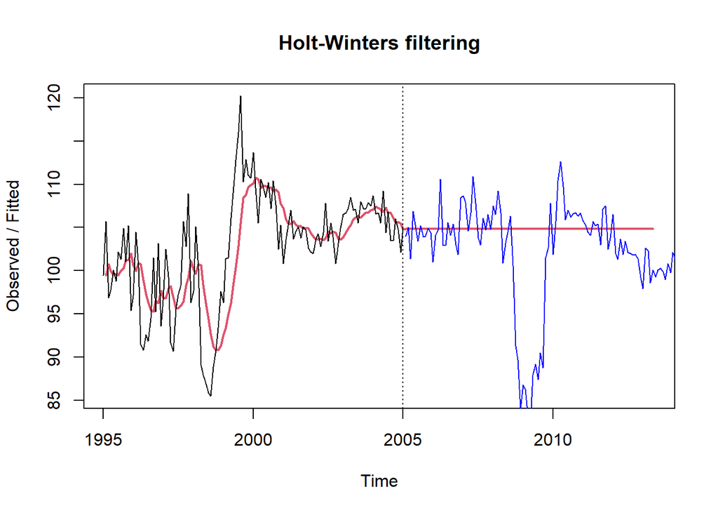

```r
pred <- predict(model,n.ahead =100)
plot(model,predicted.values = pred,lwd=2)
lines(future,col = "blue")
```

```r
print(model)
```

```
## Holt-Winters exponential smoothing without trend and without seasonal component.
##
## Call:
## HoltWinters(x = past, alpha = alpha, beta = FALSE, gamma = FALSE)
##
## Smoothing parameters:
##  alpha: 0.2
##  beta : FALSE
##  gamma: FALSE
##
## Coefficients:
##       [,1]
## a 104.8648
```

Мы построили прогноз на 100 месяцев вперед. Понятно, что прогноз будет константой, так как модель не подразумевает тренда.

## 2.2 Модель Хольта-Уинтерса с линейным трендом

Очевидным обобщением метода является добавление тренда, начнем с линейного. Модель для прогнозирования будет теперь такой
$$\widehat{y}_{t+h}=\widehat a_t+h\widehat b_t$$
, где пересчет параметров $\widehat a_t,\widehat b_t$ идет уже по следующим формулам
$$\widehat a_t = \alpha y_t+(1-\alpha)(\widehat a_{t-1}+\widehat b_{t-1})$$
$$\widehat b_t = \beta (\widehat a_t- \widehat a_{t-1})+(1-\beta)\widehat b_{t-1}$$

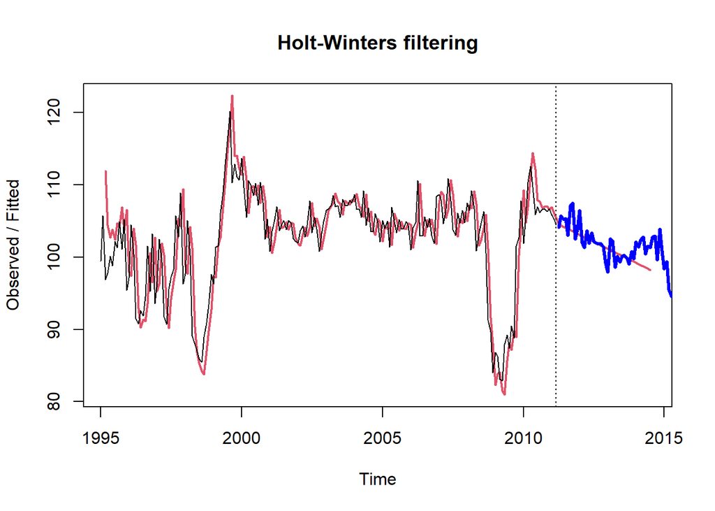

```r
past <- window(promData,end = c(2011,3))
future <- window(promData,start = c(2011,4))
model <- HoltWinters(past, gamma= FALSE)
pred <- predict(model,n.ahead =40)
plot(model,predicted.values = pred,lwd=2)
lines(future,col = "blue",lwd = 3)
```

```r
print(model)
```

```
## Holt-Winters exponential smoothing with trend and without seasonal component.
##
## Call:
## HoltWinters(x = past, gamma = FALSE)
##
## Smoothing parameters:
##  alpha: 0.7866934
##  beta : 0.1602257
##  gamma: FALSE
##
## Coefficients:
##          [,1]
## a 104.6967136
## b  -0.1611357
```

Коэффициенты $\alpha ,\beta$ мы не задавали. Они найдены были оптимизацией в смысле минимума квадрата ошибки прогноза на один шаг вперед по первой части ряда.

## 2.3 Cезонный метод Хольта-Уинтерса

Дальнейшее расширение метода это добавление аддитивной или мультипликативной сезонной компоненты с периодом сезонности $p$.

### 2.3.1 Аддитивная сезонная компонента

Модель будет теперь следующего вида.
$$\widehat{y}_{t+h}=\widehat a_t+h\widehat b_t+ \widehat s_t$$
, где пересчет параметров $\widehat a_t,\widehat b_t,\widehat s_t$ идет уже по следующим формулам
$$\widehat a_t = \alpha (y_t-\widehat s_{t-p})+(1-\alpha)(\widehat a_{t-1}+\widehat b_{t-1})$$
$$\widehat b_t = \beta (\widehat a_t- \widehat a_{t-1})+(1-\beta)\widehat b_{t-1}$$
$$\widehat s_t = \gamma (y_t-\widehat a_t)+(1-\gamma)\widehat s_{t-p}$$

### 2.3.2 Мультипликативная сезонная компонента

Модель будет теперь следующего вида.
$$\widehat{y}_{t+h}=(\widehat a_t+h\widehat b_t)\widehat s_t$$
, где пересчет параметров $\widehat a_t,\widehat b_t,\widehat s_t$ идет уже по следующим формулам
$$\widehat a_t = \alpha (y_t-\widehat s_{t-p})+(1-\alpha)(\widehat a_{t-1}+\widehat b_{t-1})$$
$$\widehat b_t = \beta (\widehat a_t- \widehat a_{t-1})+(1-\beta)\widehat b_{t-1}$$
$$\widehat s_t = \gamma (y_t/\widehat a_t)+(1-\gamma)\widehat s_{t-p}$$

Числовой пример рассмотрим на примере ряда импорта России из прошлой лекции

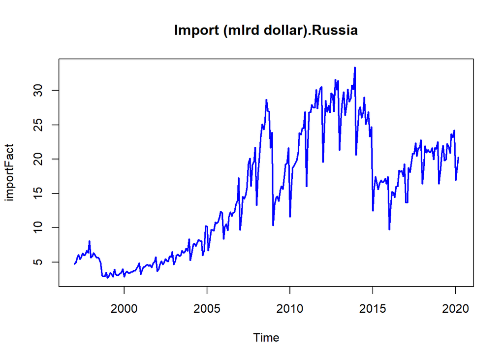

```r
import <- read.csv("./import.csv", header = TRUE)
importFact <- ts(import$Fact ,start= c(1997,1),frequency =12)
plot(importFact ,type = "l", col = "blue",lwd = 2,main = "Import (mlrd dollar).Russia")
```

Начнем прогнозирование с января 2011 года на 5 лет вперед или на 12*5 = 60 месяцев вперед. Модель будем брать мультипликативную.

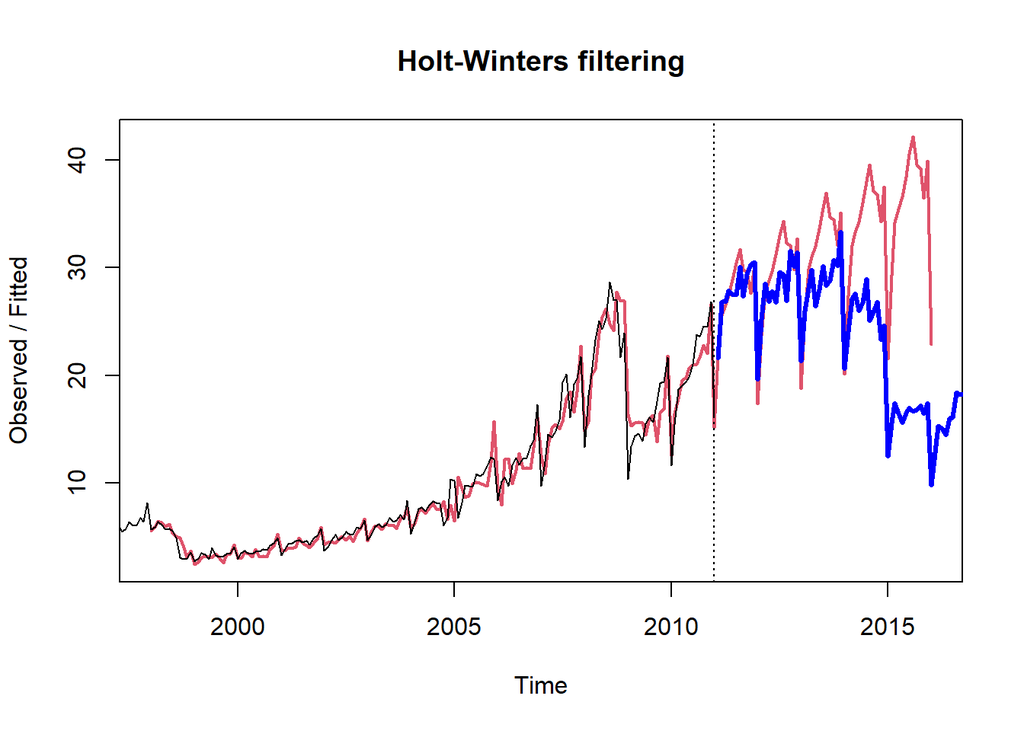

```r
past <- window(importFact,end = c(2011,1))
future <- window(importFact,start = c(2011,2))
model <- HoltWinters(past,seasonal = "mult")
pred <- predict(model,n.ahead =60)
plot(model,predicted.values = pred,lwd=2)
lines(future,col = "blue",lwd = 3)
```

```r
print(model)
```

```
## Holt-Winters exponential smoothing with trend and multiplicative seasonal component.
##
## Call:
## HoltWinters(x = past, seasonal = "mult")
##
## Smoothing parameters:
##  alpha: 0.6389659
##  beta : 0.01602396
##  gamma: 0.8568556
##
## Coefficients:
##           [,1]
## a   24.4933554
## b    0.1761019
## s1   0.8849390
## s2   1.0279983
## s3   1.0611034
## s4   1.0875641
## s5   1.1375211
## s6   1.1930511
## s7   1.2343608
## s8   1.1516480
## s9   1.1371452
## s10  1.0515990
## s11  1.1456385
## s12  0.6530003
```

2012 год спрогнозировали неплохо, а потом запахло новым кризисом:нефть стала падать,в 2015 году Украина, “Крым наш”, санкции ввели, нефть совсем упала и т.д.. Вывод. Прогнозировать на большой период имеет смысл только при неизменной динамике ряда.

Помочь увидеть недостатки и понять область применимости метода Хольта-Уинтерса поможет следующий фрейм https://shiny.ilykei.com/ANDoynikov/Holt-Winters/

# 3 Параметрические модели прогнозирования

Чаще всего построение параметрической модели временных рядов вызвано желанием успешного прогнозирования будущих значений.В этом разделе будем предполагать, что модель уже известна.

## 3.1 Прогноз с минимальной среднеквадратичной ошибкой

Через $\hat{y}_t(l)$ будем обозначать прогноз,сделанный в момент времени $t$ на $l$ интервалов времени вперед, а $y_{t+l}$ истинное значение временного ряда, которое он примет в будущем через $l$ интервалов времени после $t$.

$\hat y_{t}$ можно выразить как линейную функцию от предшествующих значений белого шума $\epsilon_t,\epsilon_{t-1},....$ Предположим, что временной ряд представлен в виде модели линейного фильтра типа скользяшего среднего
$$y_t =\sum_{j=0}^{∞}\Psi_j\epsilon_{t-j}$$

Пусть наилучшим является прогноз вида $\hat y_{t}(l)=\Psi_{l}^{∗}\epsilon_{t}+\Psi_{l+1}^{∗}\epsilon_{t-1}+\Psi_{l+2}^{∗}\epsilon_{t-2}+...=\sum_{j=0}^{∞}\Psi_{l+j}^{∗}\epsilon_{t-j}$

где веса $\Psi_{l}^{∗},\Psi_{l+1}^{∗},\Psi_{l+2}^{∗},..$ пока неизвестны их необходимо определить. Тогда так как

$y_{t+l}=\sum_{j=-∞}^{t+l}\Psi_{t+l-j}\epsilon_{j}=\sum_{j=0}^{∞}\Psi_{j}\epsilon_{t+l-j}$

Вычислим математическое ожидание квадрата ошибки прогноза

$E[y_{t+l}-\hat y_{t}(l)]^2=\sigma_{\epsilon}^2(1+\Psi_1^2+...+\Psi_{l-1}^2)+\sigma_{\epsilon}^2\sum_{j=0}^{∞}(\Psi_{l+j}-\Psi_{l+j}^{∗})^2$

Оба слагаемых в правой части последнего выражения положительны. Второе слагаемое можно сделать нулем если положить $\Psi_{l+j}=\Psi_{l+j}^{∗}$ Таким образом при $\Psi_{l+j}=\Psi_{l+j}^{∗}$ математиматическое ожидание квадрата ошибки минимально. Так мы доказали частный случай важного свойства условного математического ожидания

Условное математическое ожидание $\mathbb{E}[X \mid \mathcal{G}]$ — это наилучшее средне-квадратичное приближение $X \mathcal{G}$-измеримыми случайными величинами:

$\|X - \mathbb{E}[X\mid \mathcal{G}]\| = \inf\limits_{Z \in L^2_{\mathcal{G}}} \|X - Z\|$

См. свойства условного математического ожидания например здесь https://ru.wikipedia.org/wiki/%D0%A3%D1%81%D0%BB%D0%BE%D0%B2%D0%BD%D0%BE%D0%B5_%D0%BC%D0%B0%D1%82%D0%B5%D0%BC%D0%B0%D1%82%D0%B8%D1%87%D0%B5%D1%81%D0%BA%D0%BE%D0%B5_%D0%BE%D0%B6%D0%B8%D0%B4%D0%B0%D0%BD%D0%B8%D0%B5 Итак

$\hat y_t(l)=E[y_{t+l}|y_1,..y_t]$ - наилучший в смысле среднего квадрата ошибки прогноз. Вычислением и изучением свойст прогноза мы и будем заниматься в этой лекции для различных моделей.

### 3.1.1 Детерминированный тренд

Пусть модель временного ряда

$y_t=\mu_t+x_t$

где случайная компонента $x_t$ имеет среднее 0, а $\mu_t$- детерминированный тренд

$\hat y_t(l)=E[\mu_{t+l}+X_{t+l}|y_1,..y_t]=E[\mu_{t+l}|y_1,..y_t]+E[x_{t+l}|y_1,..y_t]=\mu_{t+l}+E[x_{t+l}]=\mu_{t+l}$

так как при $l>1$ $x_{t+l}$ не зависит от $y_1,..y_t$ и имеет среднее 0

В частности для линейного тренда $\mu_t=\beta_0+\beta_1t$ имеем прогноз

$\hat y_t(l)= \beta_0+\beta_1(t+l)$

Для сезонной модели $\mu_t=\mu_{t+12}$

$\hat y_t(l)= \mu_{t+12+l}$

Ошибка прогноза $e_t(l)= y_{t+l}-\hat y_t(l)= \mu_{t+l}+x_{t+l}-\mu_{t+l}= x_{t+l}$

Отсюда $E[e_t(l)]=E[x_{t+l}]= 0$ и $D[e_t(l)]= c_0 = D[x_t]$

## 3.2 ARIMA прогнозирование

### 3.2.1 AR(1)

На примере AR(1) модели с константой

$y_t-\mu=\phi(y_{t-1}-\mu)+\epsilon_t$

Заменим $t$ на $t+1$

$y_{t+1}-\mu=\phi(y_{t}-\mu)+\epsilon_{t+1}$

возьмем условное матеиатическое ожидание от обеих частей

$\hat y_t(1)-\mu = \phi[E(y_t|y_1,...,y_t)-\mu]+[E(\epsilon_{t+1}|y_1,...,y_t)$

Отсюда

$\hat y_t(1)=\mu+\phi(y_t-\mu)$

Для произвольного $l$

$\hat y_t(l)=\mu+\phi(\hat y_t(l-1)-\mu)$ для $l >=1$

Последнее можно переписать так

$\hat y_t(l)=\mu+\phi^{l-1}(\hat y_t(1)-\mu)$ для $l >=1$

или

$\hat y_t(l)=\mu+\phi^{l}(y_t-\mu)$

Посмотрим ошибку при прогнозировании

$e_t(1)=y_{t+1}-\hat{y}_t(1)= \phi(y_t-\mu)+\mu+\epsilon_{t+1}-\phi(y_t-\mu)+\mu= \epsilon_{t+1}$

Отсюда дисперсия ошибки прогноза

$D[e_t(1)]=\sigma_{\epsilon}^2$

Ошибка прогноза на $l$ интервалов времени

$e_t(l)=y_{t+l}-\hat{y}_t(l1)=\epsilon_{t+l}+\phi\epsilon_{t+l-1}+...+\phi^{l-1}\epsilon_{t+1}$

Но для модели AR(1) $\Psi_k= \phi^k$ поэтому

$e_t(l)=\epsilon_{t+l}+\Psi_1\epsilon_{t+l-1}+...+\Psi_{l-1}\epsilon_{t+1}$

следовательно дисперсия ошибки прогноза на $l$ интервалов

$D[e_t(l)]= \sigma_{\epsilon}^2(1+\Psi_1^2+...+\Psi_{l-1}^2)=\sigma_{\epsilon}^2\frac{1-\phi^{2l}}{1-\phi^2}$

### 3.2.2 MA(1)

Модель

$y_t=\mu+\epsilon_t-\theta\epsilon_{t-1}$

Меняем $t$ на $t+1$ и ,беря условное математическое ожидание от обеих часте, получим

$\hat{y}_t(1)= \mu-\theta E[\epsilon_t|y_1,...,y_t]=\mu-\theta\epsilon_t$

Откуда ошибка прогноза

$e_t(1)=y_{t+1}-\hat{y}_t(1)= (\mu+\epsilon_{t+1}-\theta\epsilon_{t})- (\mu-\theta\epsilon_t)= \epsilon_{t+1}$

Для произвольного числа прогнозов

$\hat{y}_t(l)= \mu+ E[\epsilon_{t+l}|y_1,...,y_t]- \theta E(\epsilon_{t+l-1}|y_1,...,y_t)=\mu$ для всех$l>1$

Для MA(1) модели $\Psi_1=-\theta$ и $\Psi_j=0$ при $j>1$ и формула

$D[e_t(l)]= \sigma_{\epsilon}^2(1+\Psi_1^2+...+\Psi_{l-1}^2)$

также справедлива.

### 3.2.3 ARMA(p,q)

Для модели произвольного порядка уравнение для прогнозирования

$\hat{y}_t(l)= \phi_1\hat{y}_{t-1}+\phi_2\hat{y}_{t-2}+...+\phi_p\hat{y}_{t-p}+\theta_0-\theta_1E(\epsilon_{t+l-1}|y_1,...,y_t)-\theta_2E(\epsilon_{t+l-2}|y_1,...,y_t)-...--\theta_qE(\epsilon_{t+l-q}|y_1,...,y_t)$

где

$E(\epsilon_{t+j}|y_1,...,y_t)= 0$ при $j>0$

$E(\epsilon_{t+j}|y_1,...,y_t)= \epsilon_{t+j}$ при $j\le 0$

Заметим, что для $j>0$ это будет прогноз $\y_{t}(j)$, а для $j\le 0$ это известное уже значение $\hat{y}_(j)= y_{t+j}$

Немного сложнее, но также можно показать, что дисперсии ошибок справедливо соотношение

$D[e_t(l)]= \sigma_{\epsilon}^2(1+\Psi_1^2+...+\Psi_{l-1}^2)$

### 3.2.4 Доверительный интервал прогноза

Здесь и понадобится выражение для дисперсии ошибок, полученное в предыдущих разделах

$D[e_t(l)]= \sigma_{\epsilon}^2(1+\Psi_1^2+...+\Psi_{l-1}^2)$ (*)

Типичным предположением относительно распределения белого шума это нормальность. На практике $\sigma_\epsilon^2$ неизвестна и должна быть оцененена из рассматриваемого временного ряда. Пусть порядки ARMA модели $p$ и $q$ определены правильно.Предположим, что ряд стационарен. Одним из рассмотренных ранее методом произведем оценку параметров модели
$$\phi_1,...\phi_p,\theta_1,...,\theta_q$$
и $\sigma_\epsilon^2$. Для нахождения доверительного интервала с использованием формулы для дисперсии необходимо определить веса $\Psi_k, k=1,...l-1$. Это мы ранее сделали, для моделей AR(1) и МА(1) в явном виде. Для произвольной модели ARMA(p,q) это можно сделать численно. Имеем модель
$$\phi_p(B)y_t = \theta_q(B)\epsilon_t$$
. Где
$$\phi_p(B)= 1- \phi_1 B- ...- \phi_p B^p$$
, а
$$\theta_q(B)=1-\theta_1 B-...-\theta_qB^q$$
Реализовав численный алгоритм деления полиномов
$$\frac{\phi_p(B)}{\theta_q(B)}$$
, найдем необходимые веса $\Psi_k, k=1,...l-1$. Таким образом дисперсия прогноза на $l$ интервалов нам известна это формула (*). Для заданного уровня доверия $(1-\alpha)100$% определим квантиль $z_{1-\alpha/2}$ стандартного нормально распределения с нулевым математическим ожиданием и дисперсией 1, тогда доверительный интервал для прогноза $\hat y_t(l)$ будет

$\hat y_t(l)\pm z_{1-\alpha/2}\sqrt{D[e_t(l)]}$

### 3.2.5 Пример cмоделированного ряда прогнозирования

Смоделируем ARMA(2,1) модель

$(1-\phi_1B-\Phi_2B^2)y_t= (1-\theta_1B)\epsilon_t$

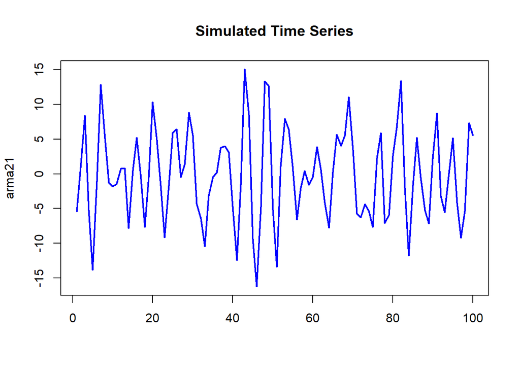

```r
phi1 <- 0.4
phi2 <- -0.5
theta1 <- 0.4
sigma <- 4
model <- list(ar = c(phi1,phi2) ,ma = theta1)
arma21 <- arima.sim(model=model,n = 100,innov=rnorm(100,0,sd=sigma))
matplot(arma21,lwd=2,type="l",col="blue",main="Simulated Time Series")
```

Произведем оценку модели методом максимального правдоподобия

```r
library(TSA)
data(arma21)
mod21 <- arima(arma21,order = c(2,0,1))
mod21$coef
```

```
##        ar1        ar2        ma1  intercept
##  0.4295651 -0.6996464  0.2488651 -0.2177654
```

```r
mod21$sigma2
```

```
## [1] 17.01486
```

Построим прогноз и 95% доверительные интервалы

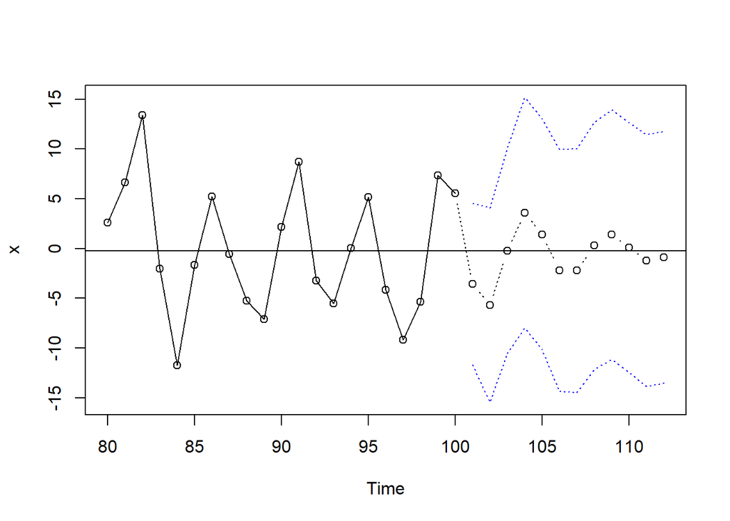

```r
plot(mod21,n.ahead=12,type='b',xlab='Time',col="blue",lty=3,n1=length(arma21)-20,lwd=1)
abline(h=coef(mod21)[names(coef(mod21))=='intercept'])
```

Значения прогнозов $\hat y_t(l)$ и стандартное отклонение прогнозов $\sqrt{D[e_{t+l}]}$ можно вычислить для все $l$ c помошью метода predict(). Доверительные интервала любого заданного уровня $(1-\alpha)100$% можно вычислить , используя квантиль нормального распределения и стандартное отклонение прогнозов $\sqrt{D[e_{t+l}]}$

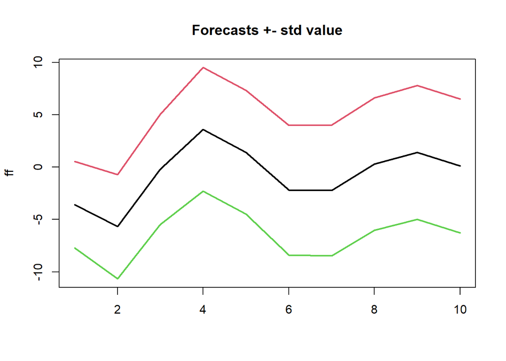

```r
forec<-predict(mod21,n.ahead = 10)
forecpl <- forec$pred+forec$se
forecmn <- forec$pred-forec$se
ff <-cbind(forec$pred,forecpl,forecmn)
matplot(ff,lty= 1,type = "l",lwd = 2,main = "Forecasts +- std value" )
```

При прогнозировании нестационарного ряда, который сводится к стационарному операцией дифференцирования (метод diff(.)), прогнозируйте сначала стационарный ряд, затем применяйте к прогнозам обратный к дифференцированию оператор суммирования (метод diffinv(.))

### 3.2.6 Пример прогнозирования смоделированного ряда

Следующий фрейм есть пример прогнозирования смоделированного ряда. Попробуйте разную длину прогноза по истории ряда. https://shiny.ilykei.com/ANDoynikov/ARMA_Model/AR_3_Forecast/

### 3.2.7 Пример прогнозирования импорта Росии

В прошлой лекции мы построили сезонную ARMA модель для импорта России. Здесь мы посмотрим на его прогнозирование. Сначала повторим построение лучшей модели из прошлой лекции без лишних комментариев. И к ряду из разностей и сезонных разностей, взятых с мая 2006 года по настоящее время подгоним сезонную SARMA(0,0,3)(0,0,1) модель.

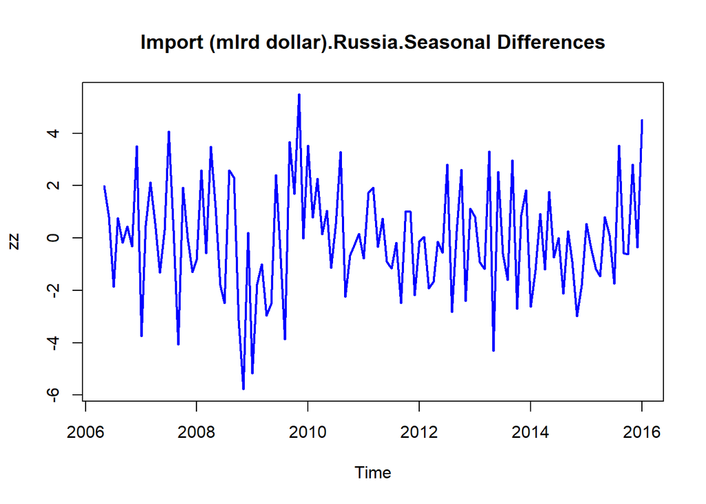

```r
y <- diff(importFact)
z <- diff(y,lag = 12)
zz <- z[100:216]
zz <- ts(zz,start= c(2006,5),frequency = 12 )
plot(zz ,type = "l", col = "blue",lwd = 2,main = "Import (mlrd dollar).Russia.Seasonal Differences")
```

```r
zz <- zz[1:116]
modelimport2 <- arima(zz,order = c(0,0,3),seasonal = list(order= c(0,0,1),period = 12 ),method = "ML")
```

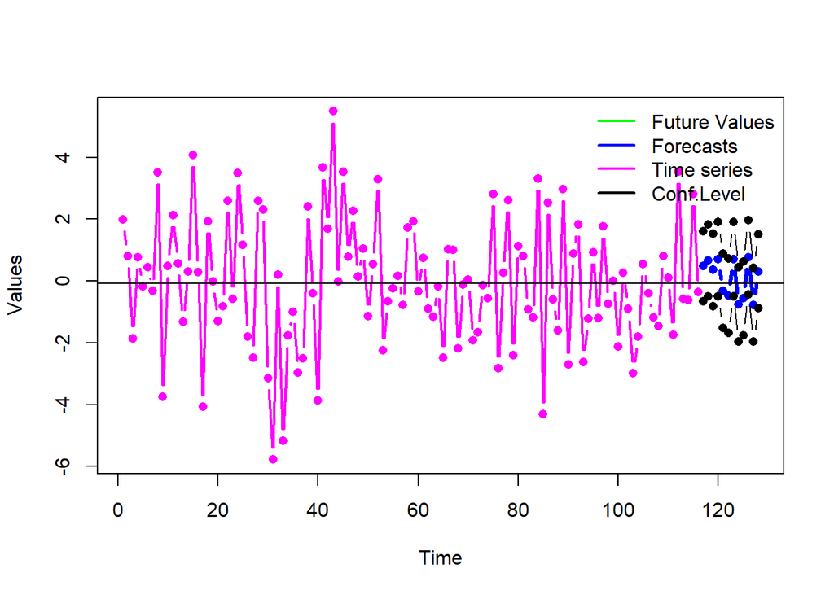

```r
getVector <- function(vv,bInd,l)
{
  c <- vector()
  if (bInd > 1)
  {
    c <- rep(NA,bInd-1)
  }
  res <- c(c,vv)
  cc <- vector()
  cc <- rep(NA,l-length(res))
  res <- c(res,cc)
  return(res)

}
lzz <- length(zz)
nforec <- 12
ll <- lzz+nforec
forecImport<-predict(modelimport2,n.ahead = nforec)
vec1 <- getVector(zz,1,ll)
vec2 <- getVector(forecImport$pred,lzz+1,ll)
vec3 <- getVector(zz,1,ll)
q<- qnorm(0.75,0,1)
dPl <- forecImport$pred + forecImport$se*q
dMn <- forecImport$pred - forecImport$se*q
vec4 <- getVector(dPl,lzz+1,ll)
vec5 <- getVector(dMn,lzz+1,ll)
res <- cbind(vec1,vec2,vec3,vec4,vec5)
matplot(res ,  type = c("b","b","b","b","b"),pch = 16,lty=1, lwd= c(2,3,2,1,1),ylab = "Values",xlab="Time",col = c("green","blue","magenta","black","black"))
abline(h=coef(modelimport2)[names(coef(modelimport2))=='intercept'])
      legend("topright",c("Future Values","Forecasts","Time series","Conf.Level"),bty="n",lwd = 2,col = c("green","blue","magenta","black"))
```

```r
firsty <- y[1:12]
iiy <- c(z,forecImport$pred)
iPl <- c(z,dPl)
iMn <- c(z,dMn)
iforec <-  diffinv(iiy,lag= 12,differences = 1,firsty)
iforecPl <-  diffinv(iPl,lag= 12,differences = 1,firsty)
iforecMn <-  diffinv(iMn,lag= 12,differences = 1,firsty)
```

Теперь проинтегрируем уже несезонные разности с начальным значением равным первому значению ряда импорта.

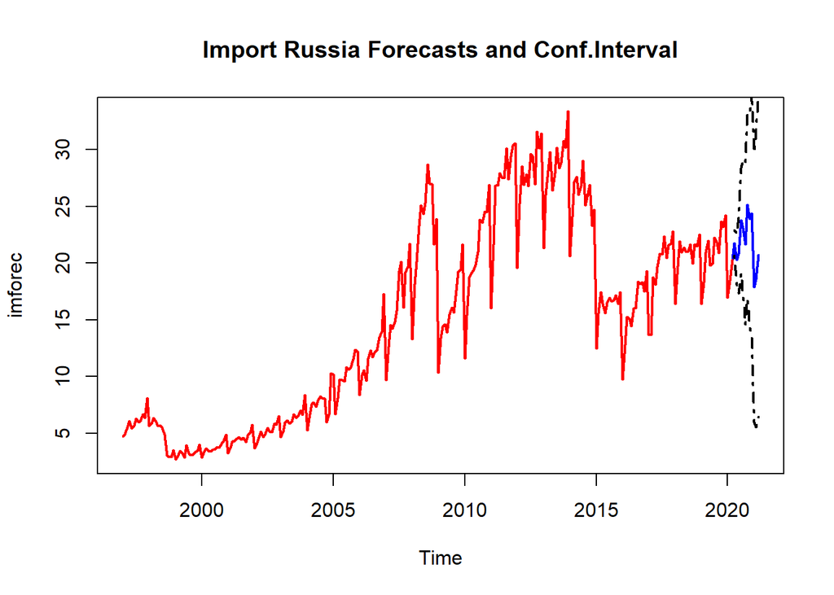

```r
  firstImport <-importFact[1]
  imforec <- diffinv(iforec,lag= 1,differences = 1,firstImport)
  imforecPl <- diffinv(iforecPl,lag= 1,differences = 1,firstImport)
  imforecMn <- diffinv(iforecMn,lag= 1,differences = 1,firstImport)
  imforec <- ts(imforec,start = c(1997,1),frequency = 12)
  imforecPl <- ts(imforecPl,start = c(1997,1),frequency = 12)
  imforecMn <- ts(imforecMn,start = c(1997,1),frequency = 12)
  imforecPl[1:length(importFact)]= NA
  imforecMn[1:length(importFact)]= NA


  plot(imforec,col = "blue",lwd = 2,type = "l", main = "Import Russia Forecasts and Conf.Interval" )
  lines(importFact,lwd = 2,col = "red")
  lines(imforecPl,lwd = 2,lty = 4,col = "black")
  lines(imforecMn,lwd = 2,lty = 4,col = "black")
```

Увидеть результаты прогнозирования для произвольного момента времени можно в следующем фрейме https://shiny.ilykei.com/ANDoynikov/Import_forecast/

## 3.3 Тестовое задание

Импортировать макро экономическую статистику `EIA weekly crude stocks, USA` недельные данные за последние 5 лет. Адрес данных http://www.finam.ru/analysis/macroevent/?str=2&ind=770&timestep=1&dind=0. К полученным данным идентифицировать и оценить две различных, но обоснованно возможных ARMA модели. Выбрать из них наиболее адекватную (выбор Объяснить). Провести анализ остатков от удаления модели:тип вероятностного распределения,автокоррелированность остатков. Построить прогноз и доверительный интервал для прогноза уровня 0.95 на 5 интервалов времени вперед.

При явной нестационарности ряда (обосновать) предварительно провести переход к преобразованным данным. Использовать преобразование данных вида:
$$y_t = x_t-x_{t_1}$$
или
$$r_t = x_t/x_{t_1}-1$$
.

# 4 Литература

- Brockwell, P. J. and Davis, R. A. (1996) Introduction to Time Series and Forecasting. Springer, New York. Sections 3.3 and 8.3.
- Бокс Дж., Дженкинс Г. (1974). Анализ временных рядов. Прогноз и управление. Пер. с англ. Вып.1-2. Мир.Москва.
- C. C. Holt (1957) Forecasting seasonals and trends by exponentially weighted moving averages, ONR Research Memorandum, Carnegie Institute of Technology 52. (reprint at http://dx.doi.org/10.1016/j.ijforecast.2003.09.015).
- P. R. Winters (1960) Forecasting sales by exponentially weighted moving averages, Management Science 6, 324–342.